# What Makes a Movie Successful?

### Jesslyn Himawan (Student #: 65088593) & Rashi Selarka (Student #: 90247693)

# Introduction

The English film industry is highly competitive, with hundreds of movies released each year. The number of movies released was significantly higher before the COVID-19 pandemic, with 873 films released in 2018 and 792 films released in 2019 [(Statista, 2023)](https://www.statista.com/statistics/187122/movie-releases-in-north-america-since-2001/#:~:text=In%202022%2C%20a%20total%20of,before%20the%20COVID%2D19%20outbreak.). In 2020, when the COVID-19 pandemic hit, the number of movies released dropped by more than half to 334. However, the film industry is slowly recovering from the pandemic, and the numbers have gradually increased over the past two years, with 406 movies in 2021 and 449 movies in 2022 [(Statista, 2023)](https://www.statista.com/statistics/187122/movie-releases-in-north-america-since-2001/#:~:text=In%202022%2C%20a%20total%20of,before%20the%20COVID%2D19%20outbreak.). The key metrics for production companies to determine the success of their movies are usually monetary, such as profits. In the 1960s, 20th Century Fox was on the brink of collapse after Cleopatra's lack of success, however, they managed to steer clear of bankruptcy after the success of The Sound of Music in 1965 [(Falco, 2015)](https://cocohitsny.wordpress.com/2015/03/01/the-hills-came-alive-the-legacy-of-the-sound-music-50-years-later/). More recently, Dreamworks Animation had to lay off 350 people to lower costs and increase profit margins, partly due to the poor performance of Rise of the Guardians released in 2012 [(Fritz, 2013)](https://www.proquest.com/newspapers/corporate-news-dreamworks-animation-posts-loss-on/docview/1312646736/se-2?accountid=14656).

[figure not shown]

Thus, understanding the factors contributing to a movie's success is crucial for production companies and producers to make informed decisions and maximize profitability. With this project, we aim to gain insights into factors that may help determine the success of a movie by performing multilinear regression analysis to develop predictive models.

We were able to find following data set on Kaggle: [Movie Dataset: Budgets, Genres, Insights (Singh, 2023)](https://www.kaggle.com/datasets/utkarshx27/movies-dataset), that contains a comprehensive set of information and industry analytics for over 3000 English movies, such as the budget, revenue, viewer ratings, genre(s), etc. Since we aim to understand factors that contribute to a movie's success from the firms' perspective, we will use `profit` (the difference between the revenue and budget) and `profit margin` (the profit relative to the revenue in %) as our measures of success. We wanted to investigate both variables because the relative nature of profit margin could make it a better indicator of success over time - it accounts for inflation over the years, unlike the raw profit values. We intend to fit 2 models - one model that predicts profit, and one that predicts the profit margin - and determine which one may be a better measure of success. Of the many available, we decided to use the following explanatory variables for both models - `budget`, `genre`, `runtime` and average viewer ratings (`vote_average`). The reason we chose budget is that a higher budget on most projects indicates greater quality of production, more qualified professionals being hired, and more marketing, all of which are expected to bring in relatively larger revenue, thus inflating profitability [(Lang, 2009)](https://www.thewrap.com/study-finds-big-budget-movies-make-greater-profits-9021/). The genres that a movie is classified into are also believed to have a correlation with the box office revenue they generate, with adventure and action films bringing in the most money [(Statista, 2023)](https://www.statista.com/statistics/188658/movie-genres-in-north-america-by-box-office-revenue-since-1995/). Multimedia research has also demonstrated that runtime (length of movie) as well as the user reviews for a movie can affect its box office performance [(E Souza, Nishijima, & Pires, 2023)](https://doi.org/10.1007/s11042-023-15169-4) [(Chintagunta, Gopinath, & Venkataraman, 2010)](https://doi.org/10.2139/ssrn.1331124), and therefore we thought these would be good predictors to consider for our models.

# Methodology

We firstly loaded the packages, data, and then cleaned it - to look at it in more detail, the Data Cleaning file can be found here: Data Cleaning.

We will be using the variables `revenue` and `budget` for each movie to calculate the values of `profit` and `profitmargin` using the following formulae:

\begin{equation*} \text{Profit} = \text{Revenue} - \text{Budget} \end{equation*}\begin{equation*} \text{Profit Margin} = \frac{\text{Profit}}{\text{Revenue}} \times 100 \end{equation*}

```python
import numpy as np
import matplotlib.pyplot as plt
import pandas as pd
import seaborn as sns
from sklearn import (
    linear_model, metrics, neural_network, pipeline, model_selection
)
import statsmodels.api as sm

%matplotlib inline
```

```python
%run data_cleaning.ipynb
%matplotlib inline
df.head()
```

|  | index | budget | genres | original_language | popularity | release_date | revenue | runtime | title | vote_average | vote_count |
| --- | --- | --- | --- | --- | --- | --- | --- | --- | --- | --- | --- |
| 0 | 0 | 237000000 | Action Adventure Fantasy Science Fiction | en | 150.437577 | 2009-12-10 | 2787965087 | 162.0 | Avatar | 7.2 | 11800 |
| 1 | 1 | 300000000 | Adventure Fantasy Action | en | 139.082615 | 2007-05-19 | 961000000 | 169.0 | Pirates of the Caribbean: At World's End | 6.9 | 4500 |
| 2 | 2 | 245000000 | Action Adventure Crime | en | 107.376788 | 2015-10-26 | 880674609 | 148.0 | Spectre | 6.3 | 4466 |
| 3 | 3 | 250000000 | Action Crime Drama Thriller | en | 112.312950 | 2012-07-16 | 1084939099 | 165.0 | The Dark Knight Rises | 7.6 | 9106 |
| 4 | 4 | 260000000 | Action Adventure Science Fiction | en | 43.926995 | 2012-03-07 | 284139100 | 132.0 | John Carter | 6.1 | 2124 |

```python
# Creating Profit variable
df["profit"] = df["revenue"] - df["budget"]

# Creating Profit Margin variable
df["profitmargin"] = (df["profit"]/df["revenue"])*100

df.head()
```

|  | index | budget | genres | original_language | popularity | release_date | revenue | runtime | title | vote_average | vote_count | profit | profitmargin |
| --- | --- | --- | --- | --- | --- | --- | --- | --- | --- | --- | --- | --- | --- |
| 0 | 0 | 237000000 | Action Adventure Fantasy Science Fiction | en | 150.437577 | 2009-12-10 | 2787965087 | 162.0 | Avatar | 7.2 | 11800 | 2550965087 | 91.499176 |
| 1 | 1 | 300000000 | Adventure Fantasy Action | en | 139.082615 | 2007-05-19 | 961000000 | 169.0 | Pirates of the Caribbean: At World's End | 6.9 | 4500 | 661000000 | 68.782518 |
| 2 | 2 | 245000000 | Action Adventure Crime | en | 107.376788 | 2015-10-26 | 880674609 | 148.0 | Spectre | 6.3 | 4466 | 635674609 | 72.180417 |
| 3 | 3 | 250000000 | Action Crime Drama Thriller | en | 112.312950 | 2012-07-16 | 1084939099 | 165.0 | The Dark Knight Rises | 7.6 | 9106 | 834939099 | 76.957232 |
| 4 | 4 | 260000000 | Action Adventure Science Fiction | en | 43.926995 | 2012-03-07 | 284139100 | 132.0 | John Carter | 6.1 | 2124 | 24139100 | 8.495522 |

Something we recognize, is that `profit`, `profit margin`, and `budget` as variables have incredibly large values compared to the rest of the dataset, and we thought it would be interesting to make them non-linear features of our linear model by taking their log instead - creating the variables `logbudget`, `logprofit` and `logprofitmargin`.

```python
import warnings
warnings.filterwarnings('ignore') # To avoid the division by 0 warning in the next cell
```

```python
#Creating values for log(budget), log(profit), and log(profitmargin)

df['logbudget'] = np.log(df["budget"]) # Creating log(budget)
df['logprofit'] = np.log(df["profit"]) # Creating log(profit)
df['logprofitmargin'] = np.log(df["profitmargin"]) # Creating log(profitmargin)

# Replacing negative infinity values for logprofit and logprofitmargin with 0

df["logprofit"].replace(-np.inf, 0, inplace=True)
df["logprofitmargin"].replace(-np.inf, 0, inplace=True)
```

For genre, the data simply provides a string of all the genres a movie belongs to - in order to make it usable in our models, we will be generating 7 dummy variables, each of which will check to see if the movie is classified in that genre or not. The 7 genres we are splitting into are **Drama, Action, Comedy, Fantasy, Horror, Animation, and Documentary**. There are multiple subgenres that we are classifying into the above genres as well (e.g. Romance and Mystery are both under Drama).

```python
# Splitting 'genres' variable into 7 genres and consequent boolean variables that indicate 1 if the movie is
# categorized in that genre and 0 if it isn't

df["isdrama"] = df["genres"].str.contains("Drama|Thriller|Mystery|Adventure|Romance|Western|Music")
df.replace({"isdrama": {False : 0, True : 1}}, inplace = True)
df["isaction"] = df["genres"].str.contains("Action|Science|War")
df.replace({"isaction": {False : 0, True : 1}}, inplace = True)
df["iscomedy"] = df["genres"].str.contains("Comedy")
df.replace({"iscomedy": {False : 0, True : 1}}, inplace = True)
df["isfantasy"] = df["genres"].str.contains("Fantasy")
df.replace({"isfantasy": {False : 0, True : 1}}, inplace = True)
df["ishorror"] = df["genres"].str.contains("Horror")
df.replace({"ishorror": {False : 0, True : 1}}, inplace = True)
df["isanimation"] = df["genres"].str.contains("Animation")
df.replace({"isanimation": {False : 0, True : 1}}, inplace = True)
df["isdoc"] = df["genres"].str.contains("Documentary")
df.replace({"isdoc": {False : 0, True : 1}}, inplace = True)
# df.head()
```

```python
# Creating a column that counts the number of genres each film got classified into for plotting

df['multiple'] = df["ishorror"] + df["iscomedy"] + df["isdrama"] + df["isfantasy"] + df["isaction"] + df["isanimation"] + df["isdoc"]
df.head()
```

|  | index | budget | genres | original_language | popularity | release_date | revenue | runtime | title | vote_average | ... | logprofit | logprofitmargin | isdrama | isaction | iscomedy | isfantasy | ishorror | isanimation | isdoc | multiple |
| --- | --- | --- | --- | --- | --- | --- | --- | --- | --- | --- | --- | --- | --- | --- | --- | --- | --- | --- | --- | --- | --- |
| 0 | 0 | 237000000 | Action Adventure Fantasy Science Fiction | en | 150.437577 | 2009-12-10 | 2787965087 | 162.0 | Avatar | 7.2 | ... | 21.659738 | 4.516330 | 1.0 | 1.0 | 0.0 | 1.0 | 0.0 | 0.0 | 0.0 | 3.0 |
| 1 | 1 | 300000000 | Adventure Fantasy Action | en | 139.082615 | 2007-05-19 | 961000000 | 169.0 | Pirates of the Caribbean: At World's End | 6.9 | ... | 20.309264 | 4.230950 | 1.0 | 1.0 | 0.0 | 1.0 | 0.0 | 0.0 | 0.0 | 3.0 |
| 2 | 2 | 245000000 | Action Adventure Crime | en | 107.376788 | 2015-10-26 | 880674609 | 148.0 | Spectre | 6.3 | ... | 20.270197 | 4.279169 | 1.0 | 1.0 | 0.0 | 0.0 | 0.0 | 0.0 | 0.0 | 2.0 |
| 3 | 3 | 250000000 | Action Crime Drama Thriller | en | 112.312950 | 2012-07-16 | 1084939099 | 165.0 | The Dark Knight Rises | 7.6 | ... | 20.542869 | 4.343250 | 1.0 | 1.0 | 0.0 | 0.0 | 0.0 | 0.0 | 0.0 | 2.0 |
| 4 | 4 | 260000000 | Action Adventure Science Fiction | en | 43.926995 | 2012-03-07 | 284139100 | 132.0 | John Carter | 6.1 | ... | 16.999343 | 2.139539 | 1.0 | 1.0 | 0.0 | 0.0 | 0.0 | 0.0 | 0.0 | 2.0 |

5 rows × 24 columns

# Data Analysis & Visualization

After data cleaning, our final dataset contains information on 3,102 films. `Genre` is now grouped into seven categories or subgenres: `Drama`, `Action`, `Comedy`, `Fantasy`, `Horror`, `Animation`, and `Documentary`.

## Genre

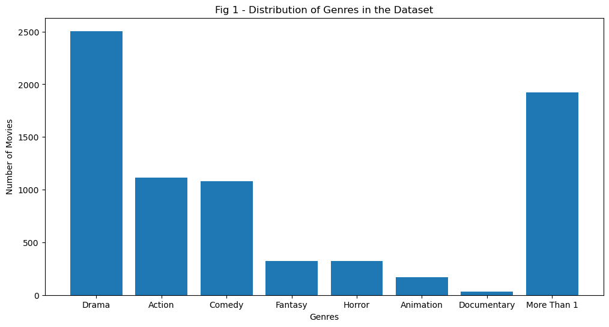

```python
# Plotting the number of occurrences for the Genres, as well as for those more than 1 genre

freq = [df["isdrama"].sum(), df["isaction"].sum(), df["iscomedy"].sum(), df["isfantasy"].sum(), df["ishorror"].sum(), df["isanimation"].sum(), df["isdoc"].sum(), len(df[df["multiple"] > 1])]

plt.figure(figsize=(12, 6))
plt.bar(x = ["Drama", "Action", "Comedy", "Fantasy", "Horror", "Animation", "Documentary", "More Than 1"], height = freq)
plt.title("Fig 1 - Distribution of Genres in the Dataset")
plt.xlabel("Genres")
plt.ylabel("Number of Movies")
plt.rc('xtick', labelsize=5)
plt.show()
```

The distribution above shows the number of movies in each genre category. From the figure above, the `Drama` category has the highest number of films, followed by `Action` and `Comedy`. `Fantasy` and `Horror` has a similar number of movies. The `Animation` category has the second lowest number of films, followed by `Documentary` with the lowest number of movies in the dataset. There is also a sizeable portion, around 2/3, of movies that are categorized as having more than 1 of the 7 genres.

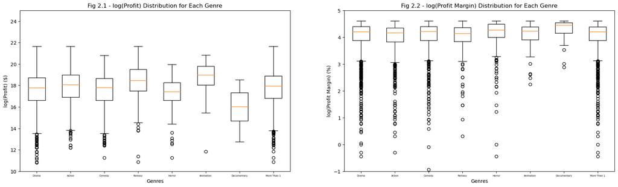

```python
# Box plot for log(Profit) for Each Genre
df.dropna(inplace = True)

fig, axes = plt.subplots(nrows=1, ncols=2, figsize=(22, 6))

axes[0].boxplot([df.loc[df["isdrama"] == 1]["logprofit"],
                 df.loc[df["isaction"] == 1]["logprofit"],
                 df.loc[df["iscomedy"] == 1]["logprofit"],
                 df.loc[df["isfantasy"] == 1]["logprofit"],
                 df.loc[df["ishorror"] == 1]["logprofit"],
                 df.loc[df["isanimation"] == 1]["logprofit"],
                 df.loc[df["isdoc"] == 1]["logprofit"],
                 df.loc[df["multiple"] > 1]["logprofit"]],
                labels=["Drama", "Action", "Comedy", "Fantasy", "Horror", "Animation", "Documentary", "More Than 1"])
axes[0].set_xlabel("Genres")
axes[0].set_ylabel("log(Profit) ($)")
axes[0].set_title("Fig 2.1 - log(Profit) Distribution for Each Genre")
axes[0].set_ylim(10, 25)  # Limiting the y-axis for clarity

axes[1].boxplot([df.loc[df["isdrama"] == 1]["logprofitmargin"],
                 df.loc[df["isaction"] == 1]["logprofitmargin"],
                 df.loc[df["iscomedy"] == 1]["logprofitmargin"],
                 df.loc[df["isfantasy"] == 1]["logprofitmargin"],
                 df.loc[df["ishorror"] == 1]["logprofitmargin"],
                 df.loc[df["isanimation"] == 1]["logprofitmargin"],
                 df.loc[df["isdoc"] == 1]["logprofitmargin"],
                 df.loc[df["multiple"] > 1]["logprofitmargin"]],
                labels=["Drama", "Action", "Comedy", "Fantasy", "Horror", "Animation", "Documentary", "More Than 1"])
axes[1].set_xlabel("Genres")
axes[1].set_ylabel("log(Profit Margin) (%)")
axes[1].set_title("Fig 2.2 - log(Profit Margin) Distribution for Each Genre")
axes[1].set_ylim(-1, 5)  # Limiting the y-axis for clarity

plt.show()
```

Judging from the box plots, movies in the `Animation` category seems to generate the highest median log profits and movies in the `Documentary` category seems to generate the lowest, but interestingly for log profit margins, the `Documentary` category appears to have the highest median. However, due to the vast spread of the data and large number of extreme values, especially considering the variation in frequency from `Fig. 1`, the median may not be the most representative metric for comparison. However, these plots allow us to get a broad idea of what the genres look like against the variables they are predicting, and can help us make inferences once we fit the models.

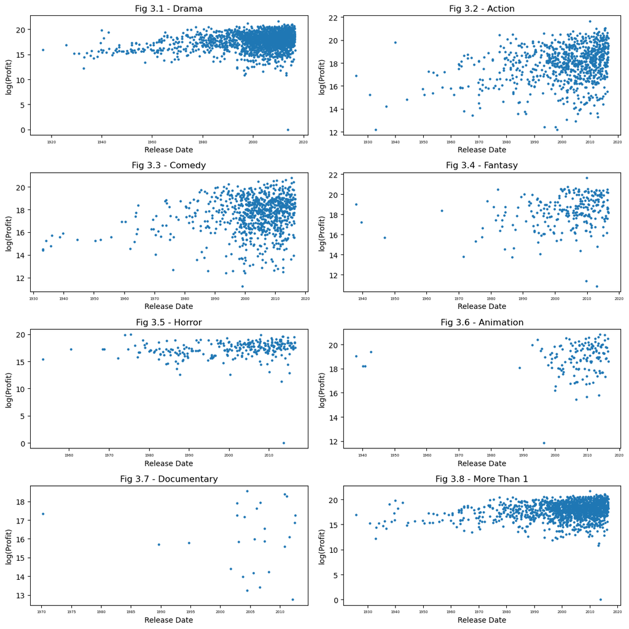

```python
# Plotting the variation of log(Profit) over time for every Genre, as well as for those more than 1 genre
pd1 = df.loc[df["isdrama"] == 1][["release_date", "logprofit"]]
pd2 = df.loc[df["isaction"] == 1][["release_date", "logprofit"]]
pd3 = df.loc[df["iscomedy"] == 1][["release_date", "logprofit"]]
pd4 = df.loc[df["isfantasy"] == 1][["release_date", "logprofit"]]
pd5 = df.loc[df["ishorror"] == 1][["release_date", "logprofit"]]
pd6 = df.loc[df["isanimation"] == 1][["release_date", "logprofit"]]
pd7 = df.loc[df["isdoc"] == 1][["release_date", "logprofit"]]
pd8 = df.loc[df["multiple"] > 1][["release_date", "logprofit"]]

fig, axes = plt.subplots(nrows=4, ncols=2, figsize=(12, 12))

axes[0, 0].scatter(pd1["release_date"], pd1["logprofit"], s=5)
axes[0, 0].set_xlabel("Release Date")
axes[0, 0].set_ylabel("log(Profit)")
axes[0, 0].set_title("Fig 3.1 - Drama")

axes[0, 1].scatter(pd2["release_date"], pd2["logprofit"], s=5)
axes[0, 1].set_xlabel("Release Date")
axes[0, 1].set_ylabel("log(Profit)")
axes[0, 1].set_title("Fig 3.2 - Action")

axes[1, 0].scatter(pd3["release_date"], pd3["logprofit"], s=5)
axes[1, 0].set_xlabel("Release Date")
axes[1, 0].set_ylabel("log(Profit)")
axes[1, 0].set_title("Fig 3.3 - Comedy")

axes[1, 1].scatter(pd4["release_date"], pd4["logprofit"], s=5)
axes[1, 1].set_xlabel("Release Date")
axes[1, 1].set_ylabel("log(Profit)")
axes[1, 1].set_title("Fig 3.4 - Fantasy")

axes[2, 0].scatter(pd5["release_date"], pd5["logprofit"], s=5)
axes[2, 0].set_xlabel("Release Date")
axes[2, 0].set_ylabel("log(Profit)")
axes[2, 0].set_title("Fig 3.5 - Horror")

axes[2, 1].scatter(pd6["release_date"], pd6["logprofit"], s=5)
axes[2, 1].set_xlabel("Release Date")
axes[2, 1].set_ylabel("log(Profit)")
axes[2, 1].set_title("Fig 3.6 - Animation")

axes[3, 0].scatter(pd7["release_date"], pd7["logprofit"], s=5)
axes[3, 0].set_xlabel("Release Date")
axes[3, 0].set_ylabel("log(Profit)")
axes[3, 0].set_title("Fig 3.7 - Documentary")

axes[3, 1].scatter(pd8["release_date"], pd8["logprofit"], s=5)
axes[3, 1].set_xlabel("Release Date")
axes[3, 1].set_ylabel("log(Profit)")
axes[3, 1].set_title("Fig 3.8 - More Than 1")

plt.tight_layout()
plt.show()
```

Looking at the figures above (`Fig 3.1` to `Fig 3.8`), it seems that movies in the `Documentary` and `Horror` genres have generated lower log profits compared to the other genres over time.

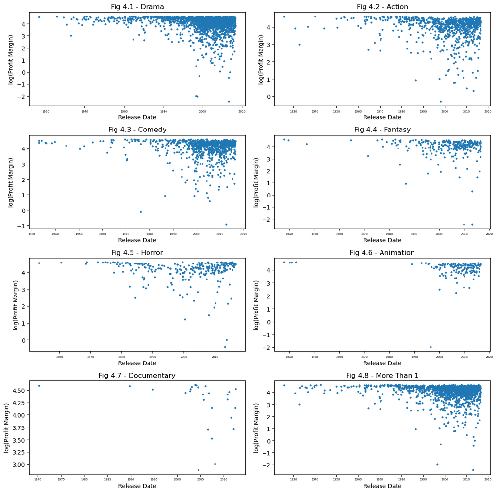

```python
# Plotting the variation of log(Profit Margin) over time for every Genre, as well as for those more than 1 genre
pd1 = df.loc[df["isdrama"] == 1][["release_date", "logprofitmargin"]]
pd2 = df.loc[df["isaction"] == 1][["release_date", "logprofitmargin"]]
pd3 = df.loc[df["iscomedy"] == 1][["release_date", "logprofitmargin"]]
pd4 = df.loc[df["isfantasy"] == 1][["release_date", "logprofitmargin"]]
pd5 = df.loc[df["ishorror"] == 1][["release_date", "logprofitmargin"]]
pd6 = df.loc[df["isanimation"] == 1][["release_date", "logprofitmargin"]]
pd7 = df.loc[df["isdoc"] == 1][["release_date", "logprofitmargin"]]
pd8 = df.loc[df["multiple"] > 1][["release_date", "logprofitmargin"]]

fig, axes = plt.subplots(nrows=4, ncols=2, figsize=(12, 12))

axes[0, 0].scatter(pd1["release_date"], pd1["logprofitmargin"], s=5)
axes[0, 0].set_xlabel("Release Date")
axes[0, 0].set_ylabel("log(Profit Margin)")
axes[0, 0].set_title("Fig 4.1 - Drama")

axes[0, 1].scatter(pd2["release_date"], pd2["logprofitmargin"], s=5)
axes[0, 1].set_xlabel("Release Date")
axes[0, 1].set_ylabel("log(Profit Margin)")
axes[0, 1].set_title("Fig 4.2 - Action")

axes[1, 0].scatter(pd3["release_date"], pd3["logprofitmargin"], s=5)
axes[1, 0].set_xlabel("Release Date")
axes[1, 0].set_ylabel("log(Profit Margin)")
axes[1, 0].set_title("Fig 4.3 - Comedy")

axes[1, 1].scatter(pd4["release_date"], pd4["logprofitmargin"], s=5)
axes[1, 1].set_xlabel("Release Date")
axes[1, 1].set_ylabel("log(Profit Margin)")
axes[1, 1].set_title("Fig 4.4 - Fantasy")

axes[2, 0].scatter(pd5["release_date"], pd5["logprofitmargin"], s=5)
axes[2, 0].set_xlabel("Release Date")
axes[2, 0].set_ylabel("log(Profit Margin)")
axes[2, 0].set_title("Fig 4.5 - Horror")

axes[2, 1].scatter(pd6["release_date"], pd6["logprofitmargin"], s=5)
axes[2, 1].set_xlabel("Release Date")
axes[2, 1].set_ylabel("log(Profit Margin)")
axes[2, 1].set_title("Fig 4.6 - Animation")

axes[3, 0].scatter(pd7["release_date"], pd7["logprofitmargin"], s=5)
axes[3, 0].set_xlabel("Release Date")
axes[3, 0].set_ylabel("log(Profit Margin)")
axes[3, 0].set_title("Fig 4.7 - Documentary")

axes[3, 1].scatter(pd8["release_date"], pd8["logprofitmargin"], s=5)
axes[3, 1].set_xlabel("Release Date")
axes[3, 1].set_ylabel("log(Profit Margin)")
axes[3, 1].set_title("Fig 4.8 - More Than 1")

plt.tight_layout()
plt.show()
```

Unlike log profit, it is slightly more unclear to decipher how log profit margins might vary by genre, so it will be interesting to see how they play a role in the profit margin model.

From the figures above (`Fig 4.1` to `Fig 4.8`), there seems to be a general trend of a higher number of movies having lower log profit margins in recent years for all genres. This could be due to several reasons, including higher competition in the film industry within recent years, or a steeper increase in production costs relative to the increase in revenues, as well as the effect of digital platforms and streaming services.

## log(Budget)

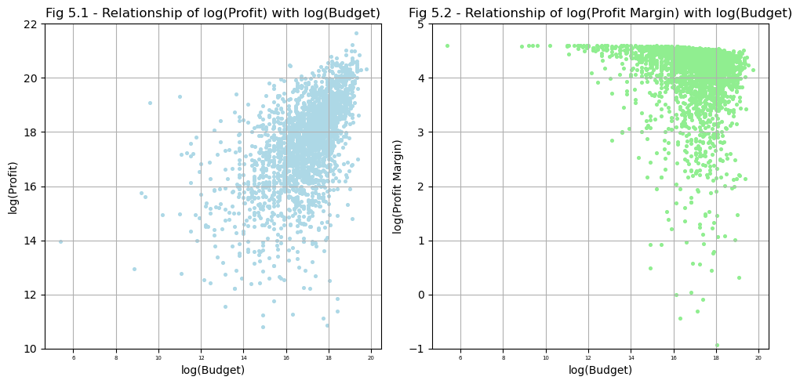

```python
# Plotting the relationship of log(Profit) and log(Profit Margin) with log(Budget)

plot1 = df.loc[:, ["logprofit", "logbudget"]]
plot2 = df.loc[:, ["logprofitmargin", "logbudget"]]

fig, axes = plt.subplots(nrows=1,ncols=2,figsize=(10,5))

plot1.plot.scatter(x = 'logbudget', y = 'logprofit', ax = axes[0],subplots=True, color='lightblue', s = 7, grid = True)
plot2.plot.scatter(x = 'logbudget', y = 'logprofitmargin', ax = axes[1],subplots=True, color='lightgreen', s = 7, grid = True)

axes[0].set_title("Fig 5.1 - Relationship of log(Profit) with log(Budget)")
axes[1].set_title("Fig 5.2 - Relationship of log(Profit Margin) with log(Budget)")

axes[0].set_xlabel("log(Budget)")
axes[1].set_xlabel("log(Budget)")
axes[0].set_ylabel("log(Profit)")
axes[1].set_ylabel("log(Profit Margin)")

axes[0].set_ylim(10, 22) # for clarity
axes[1].set_ylim(-1, 5) # for clarity

plt.tight_layout()
plt.show()
```

When comparing `log(Profit)` against `log(Budget)` using `Fig 5.1`, we can see that log budget mostly positively correlates with log profits, but there are a few points of higher budget that correlate with lower profit. These points represent blockbuster films that had large budgets but massively underperformed. Having a higher budget also means higher financial risk, as insufficient revenues would result in bigger losses. All of this probably means that the relationship between `log(Budget)` and `log(Profit)` may not be strictly linear.

When comparing `log(Profit Margin)` against `log(Budget)` using `Fig 5.2`, it's a bit hard to read what the relationship might be. While there are lot of data points concentrated around higher log budgets and higher log profit margins, there are quite a few points that are extremely low as well. As previously mentioned, higher budgets would allow for more resources to be allocated to things that could result in a more successful movie, and if the expenses are managed effectively, it can lead to a positive profit margin. However, it is not a guarantee. Other factors, such as competition, genre trends, and changing costs for making movies also play crucial roles in determining the profitability.

## Runtime

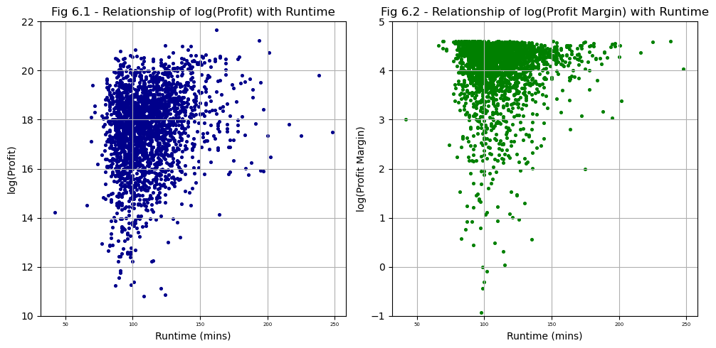

```python
# Plotting the relationship of log(Profit) and log(Profit Margin) with Runtime

plot1 = df.loc[:, ["logprofit", "runtime"]]
plot2 = df.loc[:, ["logprofitmargin", "runtime"]]

fig, axes = plt.subplots(nrows=1,ncols=2,figsize=(10,5))

plot1.plot.scatter(x = 'runtime', y = 'logprofit', ax = axes[0],subplots=True, color='darkblue', s = 7, grid = True)
plot2.plot.scatter(x = 'runtime', y = 'logprofitmargin', ax = axes[1],subplots=True, color='green', s = 7, grid = True)

axes[0].set_title("Fig 6.1 - Relationship of log(Profit) with Runtime")
axes[1].set_title("Fig 6.2 - Relationship of log(Profit Margin) with Runtime")

axes[0].set_xlabel("Runtime (mins)")
axes[1].set_xlabel("Runtime (mins)")
axes[0].set_ylabel("log(Profit)")
axes[1].set_ylabel("log(Profit Margin)")

axes[0].set_ylim(10, 22) # for clarity
axes[1].set_ylim(-1, 5) # for clarity

plt.tight_layout()
plt.show()
```

`Fig 6.1` shows a very slight positive correlation between runtime and log profits to a point, but overall does not seem to provide enough information to infer a relationship between `runtime` and `log(Profit)`. Similarly for `Fig 6.2`, apart from indicating a point (at a runtime of about 100 minutes) where `log(Profit Margin)` is extremely low, it is difficult to extract a linear trend or pattern from this graph. It is important to note that we also can't derive a causal relationship due to confounding variables.

## Viewer Rating

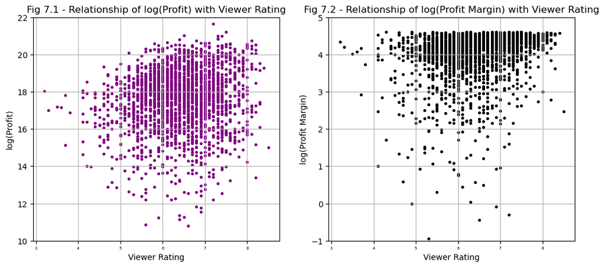

```python
# Plotting the relationship of log(Profit) and log(Profit Margin) with Viewer Rating

plot1 = df.loc[:, ["logprofit", "vote_average"]]
plot2 = df.loc[:, ["logprofitmargin", "vote_average"]]

fig, axes = plt.subplots(nrows=1,ncols=2,figsize=(12,5))

plot1.plot.scatter(x = 'vote_average', y = 'logprofit', ax = axes[0],subplots=True, color='purple', s = 7, grid = True, xlabel = 'Viewer Rating')
plot2.plot.scatter(x = 'vote_average', y = 'logprofitmargin', ax = axes[1],subplots=True, color='black', s = 7, grid = True, xlabel = 'Viewer Rating')

axes[0].set_title("Fig 7.1 - Relationship of log(Profit) with Viewer Rating")
axes[1].set_title("Fig 7.2 - Relationship of log(Profit Margin) with Viewer Rating")

axes[0].set_ylabel("log(Profit)")
axes[1].set_ylabel("log(Profit Margin)")

axes[0].set_ylim(10, 22) # for clarity
axes[1].set_ylim(-1, 5) # for clarity

plt.show()
```

As seen from `Fig 7.1`, there seems to be a general positive correlation between `Viewer Rating` and `log(Profit)`, which would make sense because a higher average viewer rating may drive more people to watch a movie, leading to higher revenue and consequently higher profits.

We can't really infer a relationship between `Viewer Rating` and `log(Profit Margin)` from `Fig 7.2`, so we'll find out upon fitting the model.

# Correlation Heat Map & Multilinear Regression Analysis

W will use explanatory variables, `log(Budget)`, `Runtime`, `Average Viewer Rating`, and `Genre` of the movies, to create two models:

1. a model that predicts the `log(profit)` for a movie.

$$\text{log(Profit)} = \beta0 + \beta1 * \text{log(budget)} + \beta2 * \text{runtime} + \beta3 * \text{viewer rating} + \beta4 * \text{is drama} +\beta5 * \text{is action} + \beta6 * \text{is comedy} + \beta7 * \text{is fantasy} + \beta8 * \text{is horror} + \beta9 * \text{is animation} + \beta10 * \text{is documentary}+\epsilon$$

2. a model that predicts the `log(profit margin)` for a movie.

$$\text{log(Profit Margin)} = \beta0 + \beta1 * \text{log(budget)} + \beta2 * \text{runtime} + \beta3 * \text{viewer rating} + \beta4 * \text{is drama} +\beta5 * \text{is action} + \beta6 * \text{is comedy} + \beta7 * \text{is fantasy} + \beta8 * \text{is horror} + \beta9 * \text{is animation} + \beta10 * \text{is documentary}+\epsilon$$

These models above do not include any interactions between the explanatory variables - therefore, we will first check the correlation between our variables to see if there is any multicollinearity and thus any interactions we may need to consider.

```python
# Dropping any null values

df.dropna(inplace=True)
```

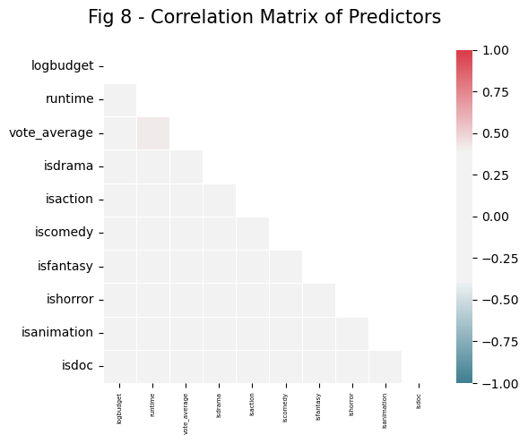

```python
# Creating a correlation heat map for the predictors to check for any multicollinearity

xvars = ["logbudget", "runtime", "vote_average", "isdrama", "isaction", "iscomedy", "isfantasy", "ishorror", "isanimation", "isdoc"]

dfcorr = df[xvars]
corr = dfcorr.corr(method='pearson')
mask = np.zeros_like(corr, dtype=bool)
mask[np.triu_indices_from(mask)] = True

fig, ax = plt.subplots(figsize=(6, 5))

cmap = sns.diverging_palette(220, 10, as_cmap=True, sep=100)

sns.heatmap(corr, mask=mask, cmap=cmap, vmin=-1, vmax=1, center=0, linewidths=.5)
fig.suptitle('Fig 8 - Correlation Matrix of Predictors', fontsize=15)
fig.tight_layout()
```

Based on `Fig 8`, there is no strong multicollinearity between any variables, and hence there are no interactions to be considered.

## Prediction Model for log(Profit)

```python
# Fitting the prediction model for log(Profit)

xvars = ["logbudget", "runtime", "vote_average", "isdrama", "isaction", "iscomedy", "isfantasy", "ishorror", "isanimation", "isdoc"]

X = df[xvars].values.reshape(-1, len(xvars))
y = df["logprofit"].values

ols = linear_model.LinearRegression()
profit_model = ols.fit(X, y)

beta_0 = profit_model.intercept_
beta_1 = profit_model.coef_[0]
beta_2 = profit_model.coef_[1]
beta_3 = profit_model.coef_[2]
beta_4 = profit_model.coef_[3]
beta_5 = profit_model.coef_[4]
beta_6 = profit_model.coef_[5]
beta_7 = profit_model.coef_[6]
beta_8 = profit_model.coef_[7]
beta_9 = profit_model.coef_[8]
beta_10 = profit_model.coef_[9]

print(f"log(Profit) model: logprofit = {beta_0:.4f} + {beta_1:.4f} logbudget + {beta_2:.4f} runtime + {beta_3:.4f} viewer rating + {beta_4:.4f} is drama + {beta_5:.4f} is action + {beta_6:.4f} is comedy + {beta_7:.4f} is fantasy + {beta_8:.4f} is horror + {beta_9:.4f} is animation + {beta_10:.4f} is documentary")
```

```
log(Profit) model: logprofit = 4.2021 + 0.5860 logbudget + 0.0063 runtime + 0.4183 viewer rating + -0.1719 is drama + 0.1623 is action + 0.1875 is comedy + 0.1953 is fantasy + 0.4871 is horror + 0.6678 is animation + 0.0763 is documentary
```

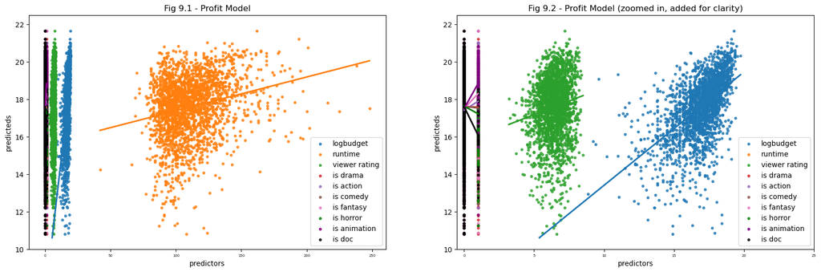

```python
# A general overlapped visualization of the log(Profit) regression model

fig, ax = plt.subplots(nrows=1,ncols=2,figsize=(20, 6))

sns.regplot(x='logbudget', y='logprofit', data=df, fit_reg=True, ci=None, ax=ax[0], scatter_kws={"s": 10}, label='logbudget')
sns.regplot(x='runtime', y='logprofit', data=df, fit_reg=True, ci=None, ax=ax[0], scatter_kws={"s": 10}, label='runtime')
sns.regplot(x='vote_average', y='logprofit', data=df, fit_reg=True, ci=None, ax=ax[0], scatter_kws={"s": 10}, label='viewer rating')
sns.regplot(x='isdrama', y='logprofit', data=df, fit_reg=True, ci=None, ax=ax[0], scatter_kws={"s": 10}, label='is drama')
sns.regplot(x='isaction', y='logprofit', data=df, fit_reg=True, ci=None, ax=ax[0], scatter_kws={"s": 10}, label='is action')
sns.regplot(x='iscomedy', y='logprofit', data=df, fit_reg=True, ci=None, ax=ax[0], scatter_kws={"s": 10}, label='is comedy')
sns.regplot(x='isfantasy', y='logprofit', data=df, fit_reg=True, ci=None, ax=ax[0], scatter_kws={"s": 10}, label='is fantasy')
sns.regplot(x='ishorror', y='logprofit', data=df, fit_reg=True, ci=None, color = 'green', ax=ax[0], scatter_kws={"s": 10}, label='is horror')
sns.regplot(x='isanimation', y='logprofit', data=df, fit_reg=True, ci=None, color = 'purple', ax=ax[0], scatter_kws={"s": 10}, label='is animation')
sns.regplot(x='isdoc', y='logprofit', data=df, fit_reg=True, ci=None, ax=ax[0], color = 'black', scatter_kws={"s": 10}, label='is doc')

ax[0].set(ylabel='predicteds', xlabel='predictors')
ax[0].legend()
ax[0].set_title("Fig 9.1 - Profit Model")
ax[0].set_ylim(10, 22.5)

# Zooming into the x-axis between -0.5 and 25 to clearly view the other predictors

sns.regplot(x='logbudget', y='logprofit', data=df, fit_reg=True, ci=None, ax=ax[1], scatter_kws={"s": 10}, label='logbudget')
sns.regplot(x='runtime', y='logprofit', data=df, fit_reg=True, ci=None, ax=ax[1], scatter_kws={"s": 10}, label='runtime')
sns.regplot(x='vote_average', y='logprofit', data=df, fit_reg=True, ci=None, ax=ax[1], scatter_kws={"s": 10}, label='viewer rating')
sns.regplot(x='isdrama', y='logprofit', data=df, fit_reg=True, ci=None, ax=ax[1], scatter_kws={"s": 10}, label='is drama')
sns.regplot(x='isaction', y='logprofit', data=df, fit_reg=True, ci=None, ax=ax[1], scatter_kws={"s": 10}, label='is action')
sns.regplot(x='iscomedy', y='logprofit', data=df, fit_reg=True, ci=None, ax=ax[1], scatter_kws={"s": 10}, label='is comedy')
sns.regplot(x='isfantasy', y='logprofit', data=df, fit_reg=True, ci=None, ax=ax[1], scatter_kws={"s": 10}, label='is fantasy')
sns.regplot(x='ishorror', y='logprofit', data=df, fit_reg=True, ci=None, color = 'green', ax=ax[1], scatter_kws={"s": 10}, label='is horror')
sns.regplot(x='isanimation', y='logprofit', data=df, fit_reg=True, ci=None, color = 'purple', ax=ax[1], scatter_kws={"s": 10}, label='is animation')
sns.regplot(x='isdoc', y='logprofit', data=df, fit_reg=True, ci=None, ax=ax[1], color = 'black', scatter_kws={"s": 10}, label='is doc')

ax[1].set(ylabel='predicteds', xlabel='predictors')
ax[1].legend()
ax[1].set_title("Fig 9.2 - Profit Model (zoomed in, added for clarity)")
ax[1].set_ylim(10, 22.5)
ax[1].set_xlim(-0.5, 25)

fig.tight_layout
plt.show()
```

## Prediction Model for log(Profit Margin)

```python
# Fitting the prediction model for log(Profit Margin)

xvars = ["logbudget", "runtime", "vote_average", "isdrama", "isaction", "iscomedy", "isfantasy", "ishorror", "isanimation", "isdoc"]

X = df[xvars].values.reshape(-1, len(xvars))
y = df["logprofitmargin"].values

ols = linear_model.LinearRegression()
profitmargin_model = ols.fit(X, y)

beta_0 = profitmargin_model.intercept_
beta_1 = profitmargin_model.coef_[0]
beta_2 = profitmargin_model.coef_[1]
beta_3 = profitmargin_model.coef_[2]
beta_4 = profitmargin_model.coef_[3]
beta_5 = profitmargin_model.coef_[4]
beta_6 = profitmargin_model.coef_[5]
beta_7 = profitmargin_model.coef_[6]
beta_8 = profitmargin_model.coef_[7]
beta_9 = profitmargin_model.coef_[8]
beta_10 = profitmargin_model.coef_[9]
residuals = (y - profitmargin_model.predict(X)).mean()

print(f"log(Profit Margin) model: logprofitmargin = {beta_0:.4f} + {beta_1:.4f} logbudget + {beta_2:.4f} runtime + {beta_3:.4f} viewer rating + {beta_4:.4f} is drama + {beta_5:.4f} is action + {beta_6:.4f} is comedy + {beta_7:.4f} is fantasy + {beta_8:.4f} is horror + {beta_9:.4f} is animation + {beta_10:.4f} is documentary")
```

```
log(Profit Margin) model: logprofitmargin = 3.9989 + -0.0829 logbudget + 0.0021 runtime + 0.1739 viewer rating + -0.0455 is drama + 0.0510 is action + 0.1032 is comedy + 0.0159 is fantasy + 0.1907 is horror + 0.1963 is animation + -0.0070 is documentary
```

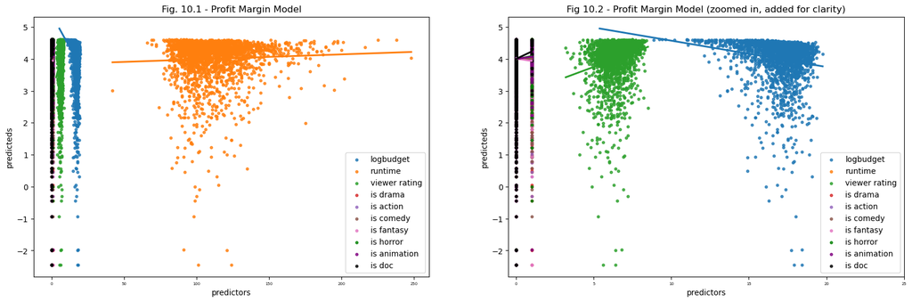

```python
# A general overlapped visualization of the log(Profit Margin) regression model

fig, ax = plt.subplots(nrows=1,ncols=2,figsize=(20, 6))

sns.regplot(x='logbudget', y='logprofitmargin', data=df, fit_reg=True, ci=None, ax=ax[0], scatter_kws={"s": 10}, label='logbudget')
sns.regplot(x='runtime', y='logprofitmargin', data=df, fit_reg=True, ci=None, ax=ax[0], scatter_kws={"s": 10}, label='runtime')
sns.regplot(x='vote_average', y='logprofitmargin', data=df, fit_reg=True, ci=None, ax=ax[0], scatter_kws={"s": 10}, label='viewer rating')
sns.regplot(x='isdrama', y='logprofitmargin', data=df, fit_reg=True, ci=None, ax=ax[0], scatter_kws={"s": 10}, label='is drama')
sns.regplot(x='isaction', y='logprofitmargin', data=df, fit_reg=True, ci=None, ax=ax[0], scatter_kws={"s": 10}, label='is action')
sns.regplot(x='iscomedy', y='logprofitmargin', data=df, fit_reg=True, ci=None, ax=ax[0], scatter_kws={"s": 10}, label='is comedy')
sns.regplot(x='isfantasy', y='logprofitmargin', data=df, fit_reg=True, ci=None, ax=ax[0], scatter_kws={"s": 10}, label='is fantasy')
sns.regplot(x='ishorror', y='logprofitmargin', data=df, fit_reg=True, ci=None, color = 'green', ax=ax[0], scatter_kws={"s": 10}, label='is horror')
sns.regplot(x='isanimation', y='logprofitmargin', data=df, fit_reg=True, ci=None, color = 'purple', ax=ax[0], scatter_kws={"s": 10}, label='is animation')
sns.regplot(x='isdoc', y='logprofitmargin', data=df, fit_reg=True, ci=None, ax=ax[0], color = 'black', scatter_kws={"s": 10}, label='is doc')

ax[0].set(ylabel='predicteds', xlabel='predictors')
ax[0].legend()
ax[0].set_title("Fig. 10.1 - Profit Margin Model")

# Zooming into the x-axis between -0.5 and 25 to clearly view the other predictors

sns.regplot(x='logbudget', y='logprofitmargin', data=df, fit_reg=True, ci=None, ax=ax[1], scatter_kws={"s": 10}, label='logbudget')
sns.regplot(x='runtime', y='logprofitmargin', data=df, fit_reg=True, ci=None, ax=ax[1], scatter_kws={"s": 10}, label='runtime')
sns.regplot(x='vote_average', y='logprofitmargin', data=df, fit_reg=True, ci=None, ax=ax[1], scatter_kws={"s": 10}, label='viewer rating')
sns.regplot(x='isdrama', y='logprofitmargin', data=df, fit_reg=True, ci=None, ax=ax[1], scatter_kws={"s": 10}, label='is drama')
sns.regplot(x='isaction', y='logprofitmargin', data=df, fit_reg=True, ci=None, ax=ax[1], scatter_kws={"s": 10}, label='is action')
sns.regplot(x='iscomedy', y='logprofitmargin', data=df, fit_reg=True, ci=None, ax=ax[1], scatter_kws={"s": 10}, label='is comedy')
sns.regplot(x='isfantasy', y='logprofitmargin', data=df, fit_reg=True, ci=None, ax=ax[1], scatter_kws={"s": 10}, label='is fantasy')
sns.regplot(x='ishorror', y='logprofitmargin', data=df, fit_reg=True, ci=None, color = 'green', ax=ax[1], scatter_kws={"s": 10}, label='is horror')
sns.regplot(x='isanimation', y='logprofitmargin', data=df, fit_reg=True, ci=None, color = 'purple', ax=ax[1], scatter_kws={"s": 10}, label='is animation')
sns.regplot(x='isdoc', y='logprofitmargin', data=df, fit_reg=True, ci=None, ax=ax[1], color = 'black', scatter_kws={"s": 10}, label='is doc')

ax[1].set(ylabel='predicteds', xlabel='predictors')
ax[1].legend()
ax[1].set_title("Fig 10.2 - Profit Margin Model (zoomed in, added for clarity)")
ax[1].set_xlim(-0.5, 25)

plt.show()
```

## Model Evaluation Statistics

Time to evaluate the models. We'll be using the R-squared value, the Root Mean Squared Error (RMSE), and the Akaike Information Criterion (AIC) to assess the fit (predicting power) and accuracy of these models, and see which one is better.

```python
# Summary for our log(Profit) Model
y_logprofit = df["logprofit"].values
x = df[xvars]
x_with_constant = sm.add_constant(x)

logprofit_model = sm.OLS(y_logprofit, x_with_constant).fit()

print("log(Profit) Model:")
logprofit_model.summary()
```

```
log(Profit) Model:
```

OLS Regression Results

| Dep. Variable: | y | R-squared: | 0.349 |
| --- | --- | --- | --- |
| Model: | OLS | Adj. R-squared: | 0.346 |
| Method: | Least Squares | F-statistic: | 125.6 |
| Date: | Sun, 02 Jul 2023 | Prob (F-statistic): | 5.47e-210 |
| Time: | 05:13:48 | Log-Likelihood: | -4017.3 |
| No. Observations: | 2354 | AIC: | 8057. |
| Df Residuals: | 2343 | BIC: | 8120. |
| Df Model: | 10 |  |  |
| Covariance Type: | nonrobust |  |  |

|  | coef | std err | t | P>\|t\| | [0.025 | 0.975] |
| --- | --- | --- | --- | --- | --- | --- |
| const | 4.2021 | 0.463 | 9.066 | 0.000 | 3.293 | 5.111 |
| logbudget | 0.5860 | 0.023 | 25.961 | 0.000 | 0.542 | 0.630 |
| runtime | 0.0063 | 0.002 | 3.568 | 0.000 | 0.003 | 0.010 |
| vote_average | 0.4183 | 0.041 | 10.260 | 0.000 | 0.338 | 0.498 |
| isdrama | -0.1719 | 0.076 | -2.251 | 0.024 | -0.322 | -0.022 |
| isaction | 0.1623 | 0.063 | 2.581 | 0.010 | 0.039 | 0.286 |
| iscomedy | 0.1875 | 0.070 | 2.693 | 0.007 | 0.051 | 0.324 |
| isfantasy | 0.1953 | 0.091 | 2.151 | 0.032 | 0.017 | 0.373 |
| ishorror | 0.4871 | 0.097 | 5.006 | 0.000 | 0.296 | 0.678 |
| isanimation | 0.6678 | 0.130 | 5.148 | 0.000 | 0.413 | 0.922 |
| isdoc | 0.0763 | 0.274 | 0.279 | 0.780 | -0.460 | 0.613 |

| Omnibus: | 1022.838 | Durbin-Watson: | 1.519 |
| --- | --- | --- | --- |
| Prob(Omnibus): | 0.000 | Jarque-Bera (JB): | 15790.569 |
| Skew: | -1.638 | Prob(JB): | 0.00 |
| Kurtosis: | 15.258 | Cond. No. | 1.96e+03 |

Notes:  
[1] Standard Errors assume that the covariance matrix of the errors is correctly specified.  
[2] The condition number is large, 1.96e+03. This might indicate that there are  
strong multicollinearity or other numerical problems.

```python
# Summary for our log(Profit Margin) Model
y_logprofitmargin = df["logprofitmargin"].values

logprofitmargin_model = sm.OLS(y_logprofitmargin, x_with_constant).fit()

print("log(Profit Margin) Model:")
logprofitmargin_model.summary()
```

```
log(Profit Margin) Model:
```

OLS Regression Results

| Dep. Variable: | y | R-squared: | 0.080 |
| --- | --- | --- | --- |
| Model: | OLS | Adj. R-squared: | 0.076 |
| Method: | Least Squares | F-statistic: | 20.30 |
| Date: | Sun, 02 Jul 2023 | Prob (F-statistic): | 1.81e-36 |
| Time: | 05:13:49 | Log-Likelihood: | -2388.5 |
| No. Observations: | 2354 | AIC: | 4799. |
| Df Residuals: | 2343 | BIC: | 4862. |
| Df Model: | 10 |  |  |
| Covariance Type: | nonrobust |  |  |

|  | coef | std err | t | P>\|t\| | [0.025 | 0.975] |
| --- | --- | --- | --- | --- | --- | --- |
| const | 3.9989 | 0.232 | 17.235 | 0.000 | 3.544 | 4.454 |
| logbudget | -0.0829 | 0.011 | -7.339 | 0.000 | -0.105 | -0.061 |
| runtime | 0.0021 | 0.001 | 2.439 | 0.015 | 0.000 | 0.004 |
| vote_average | 0.1739 | 0.020 | 8.520 | 0.000 | 0.134 | 0.214 |
| isdrama | -0.0455 | 0.038 | -1.190 | 0.234 | -0.120 | 0.029 |
| isaction | 0.0510 | 0.031 | 1.620 | 0.105 | -0.011 | 0.113 |
| iscomedy | 0.1032 | 0.035 | 2.961 | 0.003 | 0.035 | 0.172 |
| isfantasy | 0.0159 | 0.045 | 0.350 | 0.726 | -0.073 | 0.105 |
| ishorror | 0.1907 | 0.049 | 3.915 | 0.000 | 0.095 | 0.286 |
| isanimation | 0.1963 | 0.065 | 3.023 | 0.003 | 0.069 | 0.324 |
| isdoc | -0.0070 | 0.137 | -0.051 | 0.959 | -0.276 | 0.262 |

| Omnibus: | 1805.045 | Durbin-Watson: | 1.684 |
| --- | --- | --- | --- |
| Prob(Omnibus): | 0.000 | Jarque-Bera (JB): | 39520.372 |
| Skew: | -3.480 | Prob(JB): | 0.00 |
| Kurtosis: | 21.827 | Cond. No. | 1.96e+03 |

Notes:  
[1] Standard Errors assume that the covariance matrix of the errors is correctly specified.  
[2] The condition number is large, 1.96e+03. This might indicate that there are  
strong multicollinearity or other numerical problems.

### R-squared values

We see that the R-squared value for our log(Profit) model is not the greatest (0.349) in general, since R-squared values under 0.4 are considered indicative of poor explanatory power. However, these standard vary from field to field - for models in natural sciences like Chemistry, R-squared standards are higher. But in economic models, particularly those with many variables such as ours, an R-squared value near 0.3 can also be an impressive one to start with [(Valchanov, 2023)](https://365datascience.com/tutorials/statistics-tutorials/r-squared/), and this value can then be further strengthened with the additional parameters removed from or constraints set for the model.

As for our log(Profit Margin) model, the R-squared value isn't as well performing as the log(Profit) model (0.080). R-squared values this close to 0 demonstrate that the predictor variables very weakly explain the predicting variable, and we believe this is likely due to the predictors and log(Profit Margin) having a non-linear relationship. Going back to `fig. 4.1` - `4.8`, `5.2`, `6.2`, and `7.2`, there appears to be an inverted exponential or logistic curve that describes the relationship between log(Profit Margin) and the predictor variables, indicating that perhaps a logistic regression would result in a better fit for this data. The variables might still be relevant, because the R-squared value does not indicate whether certain variables should be kept or removed, but it certainly shows us that the logbudget, runtime, genre, and viewer ratings in a linear model are not doing the best job of predicting log(Profit Margin). Therefore, with reference to the R-squared statistic, the log(Profit) model is the better fitting model of the two.

### RMSE

```python
# RMSE for log(Profit) model

y = df["logprofit"].values
y = np.nan_to_num(y, neginf=0)
ypreds = profit_model.predict(X)

rmse = metrics.mean_squared_error(y, ypreds)**0.5
print(f"RMSE for log(Profit): {rmse:.4f}")
```

```
RMSE for log(Profit): 1.3333
```

```python
# RMSE for log(Profit Margin) model

y = df["logprofitmargin"].values
y = np.nan_to_num(y, neginf=0)
ypreds = profitmargin_model.predict(X)

rmse = metrics.mean_squared_error(y, ypreds)**0.5
print(f"RMSE for log(Profit Margin): {rmse:.4f}")
```

```
RMSE for log(Profit Margin): 0.6675
```

Moving onto the RMSE, there appears to be a contrasting result. The RMSE of the log(Profit Margin) model (0.6675) is lower than that of the log(profit) model (1.3333), and lower RMSEs are considered better for models since they indicate a lower standard deviation for residuals (i.e. the distance between predicted and true values). So the RMSE provides an estimation of how well the model is able to predict the target value, or its accuracy. According to the RMSE statistics found above and after considering the range of values for `log(Profit)` and `log(Profit Margin)`, the log(Profit Margin) model seems to be more accurate than the log(Profit) model.

### AIC

Lastly, the AIC. The AIC is also a measure of goodness of fit, with the lower AIC indicating a better fitting model. As seen in the tables above, the AIC for the log(Profit Margin) model (4799) is lower than that for the log(Profit) model (8057), so the log(Profit Margin) model would be considered the better fit model according to the AIC. However, there are limitations to using these statistics - which we will discuss in our next section.

# Discussion

Generally, there is a higher amount of movies with higher profits in recent years compared to the 1900s for most of the genres due to changing production costs and currency value. A concern we had with using `Profit` as an indicator of success is inflation and the diminishing value of money over time. `Profit Margin` takes into account the ratio of profit to revenue instead of absolute profit values, providing a measure of success that accounts for the scale of the movie's production and allows for a more meaningful comparison across different time periods. Therefore, we expected the model evaluation statistics to largely favour the log(Profit Margin) model. The statistic for accuracy, RMSE, corroborates that expectation, but the statistics for predictive power, the R-squared value and the AIC are conflicting - one supports the log(Profit) model and the other the log(Profit Margin) model.

The reason it is slightly more complicated as well are that while the R-squared value for our log(Profit) model may or may not indicate a decent fit model, we can still look at our visualizations and tell that perhaps these variables don't share a linear relationship with each other. So in the future, we can look to fitting a non-linear model for profit (perhaps logistic or a regression tree) and to also implement a model selection algorithm that can avoid instances of us filling our model with inappropriate parameters.

Something to note about the AIC as well is that it essentially generates scores by comparing many probably models and choosing the best one, but it doesn't say anything about the absolute quality of any of the models. i.e. if all our models are poor, it simply chose the best of a bad bunch. Therefore, an additional step after picking a model the AIC favours, is that we can consider running a hypothesis test to figure out the relationship between the explanatory variables and the outcome of interest.

It is also important to note that some of the genres used as explanatory variables, such as `Fantasy`, `Horror`, `Animation` and `Documentary`, contains significantly less movies compared to other genres in our dataset, as seen in `Fig 1`. In the future, we can look into using a larger dataset to potentially improve our model. In addition, the genre `Drama`, consists of movies in the Drama, Thriller, Mystery, Adventure, Romance, Western, and Music subgenres. In the future, breaking down the `Drama` category may also help improve our models.

# Conclusion

The fact that we chose to do linear regression (albeit with a few non-linear features) did not result in failing models, but certainly weaker models. The model sumarries found near the end that tell us this set of predictors and target variable likely share a non-linear relationship, so fitting a logistic regression or a regression tree in the future would be an interesting investigation. The explanatory variables we chose for the log(Profit) and log(Profit Margin) models also may not necessarily have been the optimal ones, and future projects in this vein should intend to implement a model selection algorithm to ensure the best parameters are present.

Following the discussion above, it is, in fact, difficult to determine if one model entirely trumps the other, since one appears to be more accurate but the other appears to have more predicting power. Hence, something that could be considered is both models working in tandem towards a *"success function"*. Similar to the production functions we've worked with before, one can consider making a success function using Profit and Profit Margin (or in our models' case, log(Profit) and log(Profit Margin)) in order to generate an overall success score for a film. Something they can look towards doing is based on the predictability and accuracy of each of the models, determining the weight / coefficient ($\alpha$) associated with each of their terms in a success function of type:

$$ \text{Success} = \alpha_1 * \text{Profit} \ \ + \ \ \alpha_2 * \text{Profit Margin}$$

# References

Chintagunta, P. K., Gopinath, S., & Venkataraman, S. (2010). The effects of online user reviews on movie box-office performance: Accounting for sequential rollout and aggregation across local markets. *SSRN Electronic Journal, 29*(5). https://doi.org/10.2139/ssrn.1331124

E Souza, T. L. D., Nishijima, M., & Pires, R. (2023). Revisiting predictions of movie economic success: random Forest applied to profits. *Multimedia tools and applications*, 1–24. Advance online publication. https://doi.org/10.1007/s11042-023-15169-4

Falco, C. (2015, March 2). *The hills came alive: The legacy of “the sound music” 50 years later*. Coco Hits New York. https://cocohitsny.wordpress.com/2015/03/01/the-hills-came-alive-the-legacy-of-the-sound-music-50-years-later/

Fritz, B. (2013). *Corporate news: dreamworks animation posts loss on big charge*. Wall Street Journal. Retrieved June 20, 2023, from https://www.proquest.com/newspapers/corporate-news-dreamworks-animation-posts-loss-on/docview/1312646736/se-2.

Lang, B. (2009, October 22). *Study finds big-budget movies make greater profits*. TheWrap. https://www.thewrap.com/study-finds-big-budget-movies-make-greater-profits-9021/

Singh, U. (2023). *Movies Dataset*. Kaggle. Retrieved from https://www.kaggle.com/datasets/utkarshx27/movies-dataset

Statista. (2023). *Number of movies released in the United States and Canada from 2000 to 2022*. Statista. https://www.statista.com/statistics/187122/movie-releases-in-north-america-since-2001/#:~:text=In%202022%2C%20a%20total%20of,before%20the%20COVID%2D19%20outbreak.

Statista. (2023, May 16). *U.S. & Canada: Film genres by total box office revenue 2023*. Statista. https://www.statista.com/statistics/188658/movie-genres-in-north-america-by-box-office-revenue-since-1995/

Valchanov, I. (2023, April 26). *Measuring explanatory power with the R-squared*. 365 Data Science. https://365datascience.com/tutorials/statistics-tutorials/r-squared/